# Introduction to Pandas

In the last two missions, we explored how the NumPy library makes working with data easier. Because we can easily work across multiple dimensions, our code is a lot easier to understand. By using vectorized operations instead of loops, our code runs faster with larger data.

Although NumPy provides fundamental structures and tools that make working with data easier, there are several things that limit its usefulness:

- The lack of support for column names forces us to frame questions as multi-dimensional array operations.
- Support for only one data type per ndarray makes it more difficult to work with data that contains both numeric and string data.
- There are lots of low level methods, but there are many common analysis patterns that don't have pre-built methods.

The **pandas library** provides solutions to all of these pain points and more. Pandas is not so much a replacement for NumPy as an extension of NumPy. The underlying code for pandas uses the NumPy library extensively, which means the concepts you've been learning will come in handy as you begin to learn more about pandas.

The primary data structure in pandas is called a **dataframe**. Dataframes are the pandas equivalent of a Numpy 2D ndarray, with a few key differences:

- Axis values can have string labels, not just numeric ones.
- Dataframes can contain columns with multiple data types: including integer, float, and string.

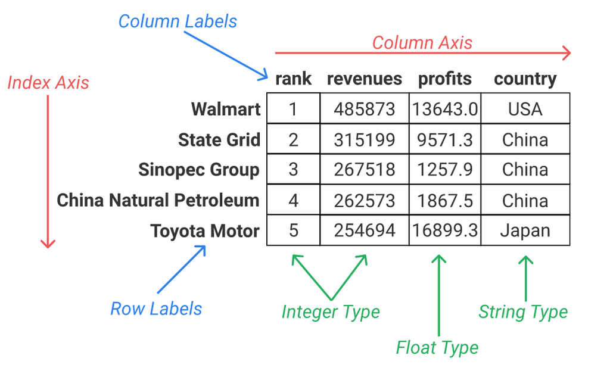

As we learn pandas, we'll work with a data set from Fortune magazine's 2017 Global 500 list, which ranks the top 500 corporations worldwide by revenue.

[figure not shown]

The data set is a CSV file called f500.csv. Here is a data dictionary for some of the columns in the CSV:

- company: Name of the company.
- rank: Global 500 rank for the company.
- revenues: Company's total revenue for the fiscal year, in millions of dollars (USD).
- revenue_change: Percentage change in revenue between the current and prior fiscal year.
- profits: Net income for the fiscal year, in millions of dollars (USD).
- ceo: Company's Chief Executive Officer.
- industry: Industry in which the company operates.
- sector: Sector in which the company operates.
- previous_rank: Global 500 rank for the company for the prior year.
- country: Country in which the company is headquartered.

```python
import pandas as pd

f500 = pd.read_csv('f500.csv',index_col=0)

f500_type = type(f500)
f500_shape = f500.shape
```

```python
f500.head(3)
```

| company | rank | revenues | revenue_change | profits | assets | profit_change | ceo | industry | sector | previous_rank | country | hq_location | website | years_on_global_500_list | employees | total_stockholder_equity |
| --- | --- | --- | --- | --- | --- | --- | --- | --- | --- | --- | --- | --- | --- | --- | --- | --- |
| Walmart | 1 | 485873 | 0.8 | 13643.0 | 198825 | -7.2 | C. Douglas McMillon | General Merchandisers | Retailing | 1 | USA | Bentonville, AR | http://www.walmart.com | 23 | 2300000 | 77798 |
| State Grid | 2 | 315199 | -4.4 | 9571.3 | 489838 | -6.2 | Kou Wei | Utilities | Energy | 2 | China | Beijing, China | http://www.sgcc.com.cn | 17 | 926067 | 209456 |
| Sinopec Group | 3 | 267518 | -9.1 | 1257.9 | 310726 | -65.0 | Wang Yupu | Petroleum Refining | Energy | 4 | China | Beijing, China | http://www.sinopec.com | 19 | 713288 | 106523 |

```python
f500.tail(3)
```

| company | rank | revenues | revenue_change | profits | assets | profit_change | ceo | industry | sector | previous_rank | country | hq_location | website | years_on_global_500_list | employees | total_stockholder_equity |
| --- | --- | --- | --- | --- | --- | --- | --- | --- | --- | --- | --- | --- | --- | --- | --- | --- |
| Wm. Morrison Supermarkets | 498 | 21741 | -11.3 | 406.4 | 11630 | 20.4 | David T. Potts | Food and Drug Stores | Food & Drug Stores | 437 | Britain | Bradford, Britain | http://www.morrisons.com | 13 | 77210 | 5111 |
| TUI | 499 | 21655 | -5.5 | 1151.7 | 16247 | 195.5 | Friedrich Joussen | Travel Services | Business Services | 467 | Germany | Hanover, Germany | http://www.tuigroup.com | 23 | 66779 | 3006 |
| AutoNation | 500 | 21609 | 3.6 | 430.5 | 10060 | -2.7 | Michael J. Jackson | Specialty Retailers | Retailing | 0 | USA | Fort Lauderdale, FL | http://www.autonation.com | 12 | 26000 | 2310 |

Another feature that makes pandas better for working with data is that dataframes can contain more than one data type:

We can use the `DataFrame.dtypes` attribute (similar to NumPy's ndarray.dtype attribute) to return information about the types of each column.

```python
f500.dtypes
```

```
rank                          int64
revenues                      int64
revenue_change              float64
profits                     float64
assets                        int64
profit_change               float64
ceo                          object
industry                     object
sector                       object
previous_rank                 int64
country                      object
hq_location                  object
website                      object
years_on_global_500_list      int64
employees                     int64
total_stockholder_equity      int64
dtype: object
```

```python
f500.info()
```

```
<class 'pandas.core.frame.DataFrame'>
Index: 500 entries, Walmart to AutoNation
Data columns (total 16 columns):
 #   Column                    Non-Null Count  Dtype
---  ------                    --------------  -----
 0   rank                      500 non-null    int64
 1   revenues                  500 non-null    int64
 2   revenue_change            498 non-null    float64
 3   profits                   499 non-null    float64
 4   assets                    500 non-null    int64
 5   profit_change             436 non-null    float64
 6   ceo                       500 non-null    object
 7   industry                  500 non-null    object
 8   sector                    500 non-null    object
 9   previous_rank             500 non-null    int64
 10  country                   500 non-null    object
 11  hq_location               500 non-null    object
 12  website                   500 non-null    object
 13  years_on_global_500_list  500 non-null    int64
 14  employees                 500 non-null    int64
 15  total_stockholder_equity  500 non-null    int64
dtypes: float64(3), int64(7), object(6)
memory usage: 66.4+ KB
```

### Selecting a column from a DataFrame by Label

Because our axes in pandas have labels, we can select data using those labels — unlike in NumPy, where we needed to know the exact index location. To do this, we can use the DataFrame.loc[] attribute. The syntax for DataFrame.loc[] is:

```
df.loc[row_label, column_label]
```

Notice that we use brackets ([]) instead of parentheses (()) when selecting by location.

Let's select a single column by specifying a single label:

```python
f500.loc[:, 'rank']
```

```
company
Walmart                             1
State Grid                          2
Sinopec Group                       3
China National Petroleum            4
Toyota Motor                        5
                                 ...
Teva Pharmaceutical Industries    496
New China Life Insurance          497
Wm. Morrison Supermarkets         498
TUI                               499
AutoNation                        500
Name: rank, Length: 500, dtype: int64
```

We can also use the following shortcut to select a single column:

```python
rank_col = f500["rank"]
print(rank_col)
```

```
company
Walmart                             1
State Grid                          2
Sinopec Group                       3
China National Petroleum            4
Toyota Motor                        5
                                 ...
Teva Pharmaceutical Industries    496
New China Life Insurance          497
Wm. Morrison Supermarkets         498
TUI                               499
AutoNation                        500
Name: rank, Length: 500, dtype: int64
```

```python
print(type(rank_col))
```

```
<class 'pandas.core.series.Series'>
```

## Introduction to Series.

On the last screen, we observed that when you select just one column of a dataframe, you get a new pandas type: a series object. Series is the pandas type for one-dimensional objects. Anytime you see a 1D pandas object, it will be a series. Anytime you see a 2D pandas object, it will be a dataframe.

In fact, you can think of a dataframe as a collection of series objects, which is similar to how pandas stores the data behind the scenes.

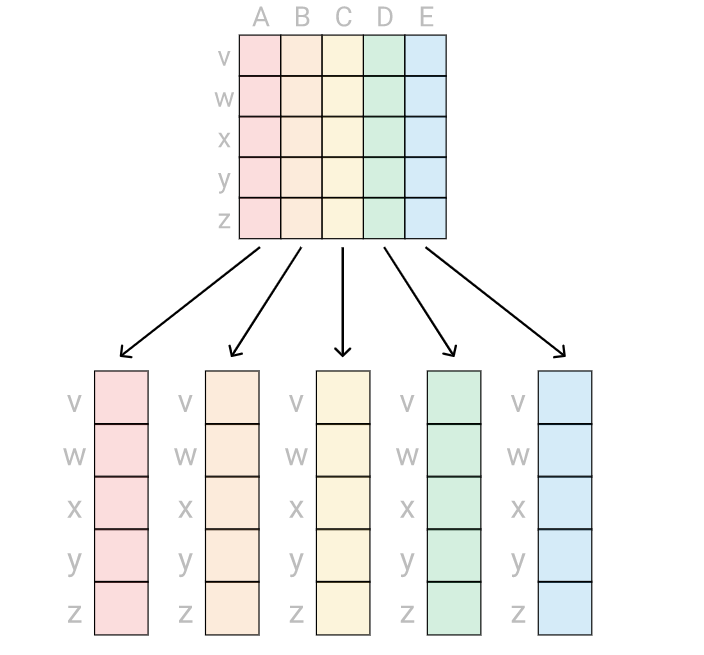

### Selecting columns from a dataframe by label (cont.)

Below, we use a list of labels to select specific columns:

```python
f500.loc[:, ['country', 'rank']]
```

| company | country | rank |
| --- | --- | --- |
| Walmart | USA | 1 |
| State Grid | China | 2 |
| Sinopec Group | China | 3 |
| China National Petroleum | China | 4 |
| Toyota Motor | Japan | 5 |
| ... | ... | ... |
| Teva Pharmaceutical Industries | Israel | 496 |
| New China Life Insurance | China | 497 |
| Wm. Morrison Supermarkets | Britain | 498 |
| TUI | Germany | 499 |
| AutoNation | USA | 500 |

500 rows × 2 columns

```python
f500[['country', 'rank']]
```

| company | country | rank |
| --- | --- | --- |
| Walmart | USA | 1 |
| State Grid | China | 2 |
| Sinopec Group | China | 3 |
| China National Petroleum | China | 4 |
| Toyota Motor | Japan | 5 |
| ... | ... | ... |
| Teva Pharmaceutical Industries | Israel | 496 |
| New China Life Insurance | China | 497 |
| Wm. Morrison Supermarkets | Britain | 498 |
| TUI | Germany | 499 |
| AutoNation | USA | 500 |

500 rows × 2 columns

Let's finish by using **a slice object with labels to select specific columns**:

```python
f500.loc[:, 'rank':'profits']
```

| company | rank | revenues | revenue_change | profits |
| --- | --- | --- | --- | --- |
| Walmart | 1 | 485873 | 0.8 | 13643.0 |
| State Grid | 2 | 315199 | -4.4 | 9571.3 |
| Sinopec Group | 3 | 267518 | -9.1 | 1257.9 |
| China National Petroleum | 4 | 262573 | -12.3 | 1867.5 |
| Toyota Motor | 5 | 254694 | 7.7 | 16899.3 |
| ... | ... | ... | ... | ... |
| Teva Pharmaceutical Industries | 496 | 21903 | 11.5 | 329.0 |
| New China Life Insurance | 497 | 21796 | -13.3 | 743.9 |
| Wm. Morrison Supermarkets | 498 | 21741 | -11.3 | 406.4 |
| TUI | 499 | 21655 | -5.5 | 1151.7 |
| AutoNation | 500 | 21609 | 3.6 | 430.5 |

500 rows × 4 columns

We again get a dataframe object, with all of the columns from the first up until — **and including** — the last column in our slice. Also note there is no shortcut for selecting column slices.

A summary of the techniques we've learned so far is below:

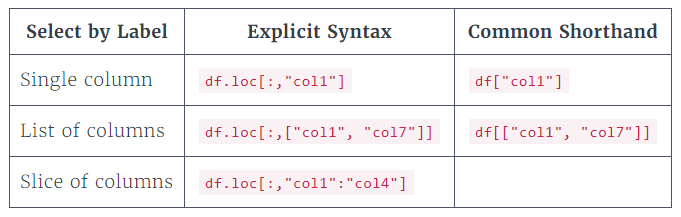

```python
countries = f500['country']
revenues_years = f500[['revenues','years_on_global_500_list']]
ceo_to_sector = f500.loc[:,"ceo" : "sector"]
```

### Selecting rows from a DataFrame by Label

Now that we've learned how to select columns by label, let's learn how to select rows using the labels of the **index** axis. We use the same syntax to select rows from a dataframe as we do for columns:

```
df.loc[row_label, column_label]
```

#### Select a single row

```python
single_row = f500.loc["Sinopec Group"]
print(type(single_row))
single_row
```

```
<class 'pandas.core.series.Series'>
```

```
rank                                             3
revenues                                    267518
revenue_change                                -9.1
profits                                     1257.9
assets                                      310726
profit_change                                  -65
ceo                                      Wang Yupu
industry                        Petroleum Refining
sector                                      Energy
previous_rank                                    4
country                                      China
hq_location                         Beijing, China
website                     http://www.sinopec.com
years_on_global_500_list                        19
employees                                   713288
total_stockholder_equity                    106523
Name: Sinopec Group, dtype: object
```

#### Select a list of rows

```python
list_rows = f500.loc[["Toyota Motor", "Walmart"]]
print(type(list_rows))

list_rows
```

```
<class 'pandas.core.frame.DataFrame'>
```

| company | rank | revenues | revenue_change | profits | assets | profit_change | ceo | industry | sector | previous_rank | country | hq_location | website | years_on_global_500_list | employees | total_stockholder_equity |
| --- | --- | --- | --- | --- | --- | --- | --- | --- | --- | --- | --- | --- | --- | --- | --- | --- |
| Toyota Motor | 5 | 254694 | 7.7 | 16899.3 | 437575 | -12.3 | Akio Toyoda | Motor Vehicles and Parts | Motor Vehicles & Parts | 8 | Japan | Toyota, Japan | http://www.toyota-global.com | 23 | 364445 | 157210 |
| Walmart | 1 | 485873 | 0.8 | 13643.0 | 198825 | -7.2 | C. Douglas McMillon | General Merchandisers | Retailing | 1 | USA | Bentonville, AR | http://www.walmart.com | 23 | 2300000 | 77798 |

#### Select a slice object with labels

For selection using slices, we can use the shortcut below. This is the reason we can't use this shortcut for columns - because it's reserved for use with rows:

```python
slice_rows = f500["State Grid":"Toyota Motor"]
print(type(slice_rows))
slice_rows
```

```
<class 'pandas.core.frame.DataFrame'>
```

| company | rank | revenues | revenue_change | profits | assets | profit_change | ceo | industry | sector | previous_rank | country | hq_location | website | years_on_global_500_list | employees | total_stockholder_equity |
| --- | --- | --- | --- | --- | --- | --- | --- | --- | --- | --- | --- | --- | --- | --- | --- | --- |
| State Grid | 2 | 315199 | -4.4 | 9571.3 | 489838 | -6.2 | Kou Wei | Utilities | Energy | 2 | China | Beijing, China | http://www.sgcc.com.cn | 17 | 926067 | 209456 |
| Sinopec Group | 3 | 267518 | -9.1 | 1257.9 | 310726 | -65.0 | Wang Yupu | Petroleum Refining | Energy | 4 | China | Beijing, China | http://www.sinopec.com | 19 | 713288 | 106523 |
| China National Petroleum | 4 | 262573 | -12.3 | 1867.5 | 585619 | -73.7 | Zhang Jianhua | Petroleum Refining | Energy | 3 | China | Beijing, China | http://www.cnpc.com.cn | 17 | 1512048 | 301893 |
| Toyota Motor | 5 | 254694 | 7.7 | 16899.3 | 437575 | -12.3 | Akio Toyoda | Motor Vehicles and Parts | Motor Vehicles & Parts | 8 | Japan | Toyota, Japan | http://www.toyota-global.com | 23 | 364445 | 157210 |

More examples:

```python
toyota = f500.loc['Toyota Motor']
drink_companies = f500.loc[['Anheuser-Busch InBev', 'Coca-Cola', 'Heineken Holding']]
middle_companies = f500.loc['Tata Motors': 'Nationwide' , 'rank':'country']
```

#### Series vs Dataframes

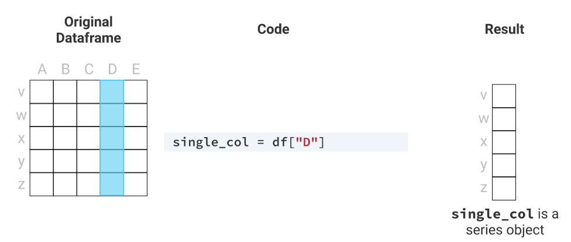

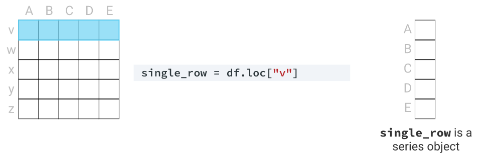

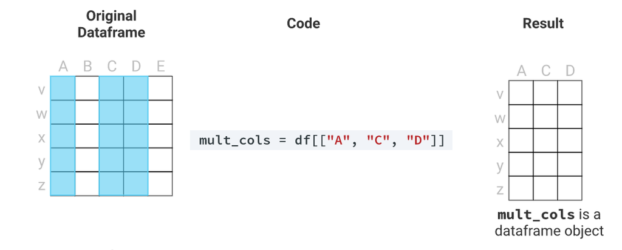

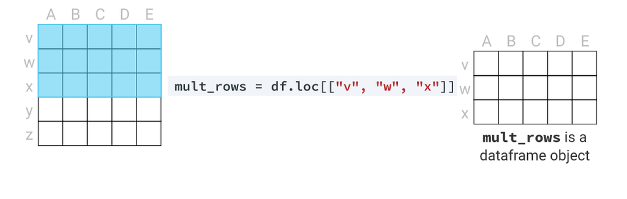

### Value Counts Method

Because series and dataframes are two distinct objects, they have their own unique methods. Let's look at an example of a series method next - the Series.value_counts() method. This method displays each unique non-null value in a column and their counts in order.

First, we'll select just one column from the f500 dataframe:

```python
sectors = f500["sector"]
print(type(sectors))
```

```
<class 'pandas.core.series.Series'>
```

Next, we'll substitute "Series" in Series.value_counts() with the name of our sectors series, like below:

```python
sectors_value_counts = sectors.value_counts()
print(sectors_value_counts)
```

```
Financials                       118
Energy                            80
Technology                        44
Motor Vehicles & Parts            34
Wholesalers                       28
Health Care                       27
Food & Drug Stores                20
Transportation                    19
Telecommunications                18
Retailing                         17
Food, Beverages & Tobacco         16
Materials                         16
Industrials                       15
Aerospace & Defense               14
Engineering & Construction        13
Chemicals                          7
Hotels, Restaurants & Leisure      3
Business Services                  3
Household Products                 3
Media                              3
Apparel                            2
Name: sector, dtype: int64
```

In the resulting series, we can see each unique non-null value in the column and their counts.

Let's see what happens when we try to use the `Series.value_counts()` method with a dataframe. First, we'll select the `sector` and `industry` columns to create a dataframe named `sectors_industries`:

```python
sectors_industries = f500[["sector", "industry"]]
print(type(sectors_industries))
```

```
<class 'pandas.core.frame.DataFrame'>
```

Then, we'll try to use the `value_counts()` method:

```python
si_value_counts = sectors_industries.value_counts()
print(si_value_counts)
```

```
---------------------------------------------------------------------------
AttributeError                            Traceback (most recent call last)
<ipython-input-32-25ec7ca958fd> in <module>
----> 1 si_value_counts = sectors_industries.value_counts()
      2 print(si_value_counts)

~\Anaconda3\lib\site-packages\pandas\core\generic.py in __getattr__(self, name)
   5272             if self._info_axis._can_hold_identifiers_and_holds_name(name):
   5273                 return self[name]
-> 5274             return object.__getattribute__(self, name)
   5275
   5276     def __setattr__(self, name: str, value) -> None:

AttributeError: 'DataFrame' object has no attribute 'value_counts'
```

`value_counts` is only for series...

### Selecting items from a Series by Label

As with dataframes, we can use `Series.loc[]` to select items from a series using single labels, a list, or a slice object. We can also omit `loc[]` and use bracket shortcuts for all three:

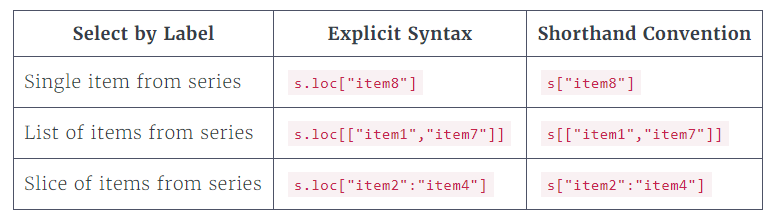

```python
# Examples

countries = f500['country']
countries_counts = countries.value_counts()

india = countries_counts['India']
north_america = countries_counts[['USA','Canada','Mexico']]
```

## Summary

Let's take a look at a summary of all the different label selection mechanisms we've learned in this mission:

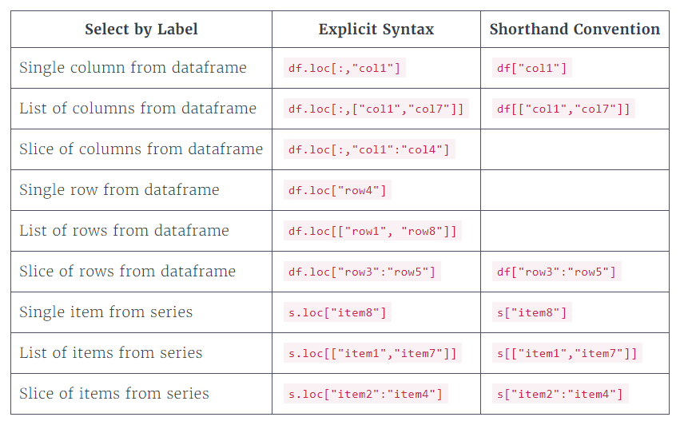

```python
# Example:

big_movers = f500.loc[['Aviva','HP','JD.com','BHP Billiton'],['rank','previous_rank']]

bottom_companies = f500.loc['National Grid':'AutoNation', ['rank','sector','country']]
```